# The celestial sphere I

This is the first of two related packets. The packets together cover the following topics:

- Spherical coordinate systems
  - latitude and longitude
  - horizontal coordinate system: altitude and elevation
  - equatorial coordinate system: declination and right ascension
- Celestial motion
  - ecliptic
  - equinoxes and solstices
  - rotation and revolution
- Measurement
  - sextant
  - anatomical features
  - constellations and asterisms

## Astronomical coordinate systems

Throughout this course we will be faced with the fact that we cannot easily determine the distance to an object that we can see in space: We only see in the two dimensions spanning the sky and have no “depth perception”. This two-dimensional space is called the **celestial sphere**. The two dimensions are called **latitude** (up and down) and **longitude** (side-to-side). Points on the celestial sphere are labeled by two angles called **celestial coordinates**. Sizes of astronomical objects on this sphere are measured in these angles.

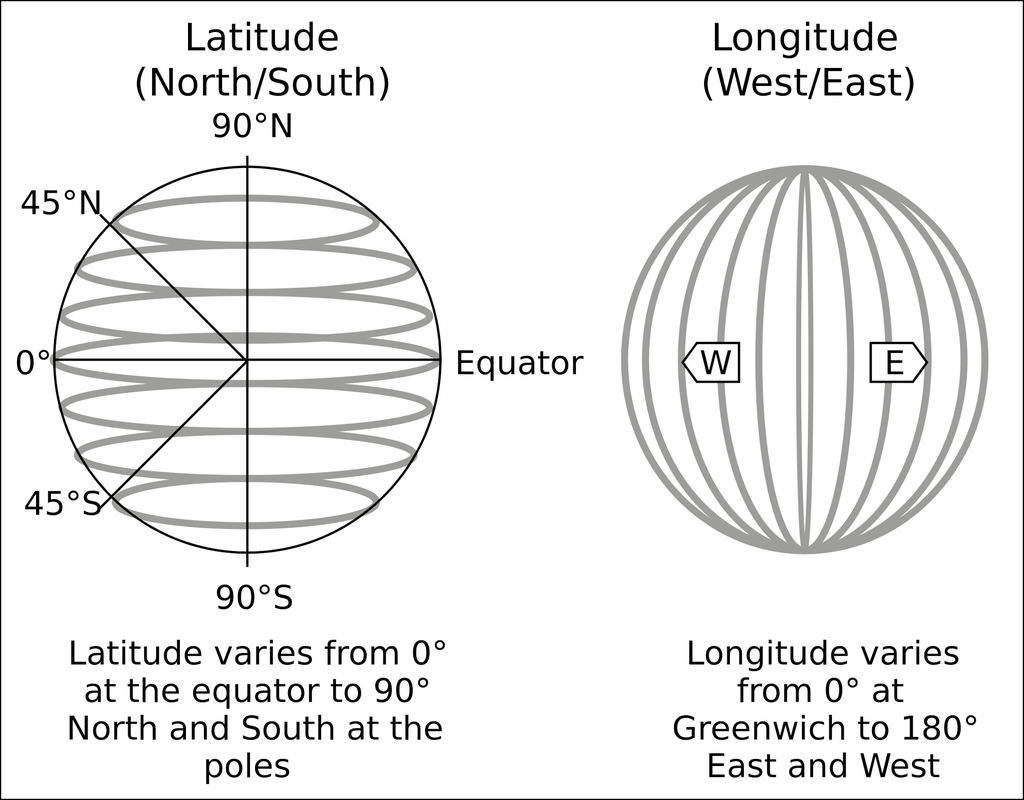

On the surface of the earth, the coordinate for latitude (conventionally denoted by the Greek lower-case letter phi $\phi$) is defined relative to the **equator**: The points of latitude $\phi = 0{^\circ}$ are the equator. There is only one point at a latitude of $\phi = 90{^\circ}$ N (a.k.a. $90{^\circ}$ north-latitude) which is the North Pole. To define the coordinate of longitude, we need a second great circle perpendicular to the equator called the **prime meridian**. For historical reasons, the prime meridian is defined to go through the [Royal Observatory in Greenwich Park](https://en.wikipedia.org/wiki/Royal_Observatory,_Greenwich) in London, England with the angle increasing from $0{^\circ}$ to $180{^\circ}$ east or west.

### Problem 1

> 1. Using a globe or a map, find a major city located near the coordinates $31{^\circ}$ north latitude and $30{^\circ}$ east longitude.
> 2. Find the geographic coordinates of TJ by using a globe. Then find more accurate coordinates using an altlas or map. *After* you have done this with a real map, check your answer using a map app.

### Problem 2

> In `ss_aristarchus` we will learn how to determine the radius of the Earth. The modern accepted value is $R=6,370$ km.
> 1. Calculate the distance on the surface of Earth corresponding to $1{^\circ}$ and $0.1{^\circ}$.
> 2. What is the answer on a sphere of radius $R$?

The previous problem makes it clear that we need to subdivide degrees if we are to be able to navigate to within a precision of hundreds of kilometers. The most common subdivisions are **minutes of arc** and **seconds of arc**. One **arcminute** is $\frac{1}{60}$<sup>th</sup> of a degree. It is denoted $1' \approx 0.0167{^\circ}$. Similarly, one **arcsecond** is is $\frac{1}{60}$<sup>th</sup> of an arcminute and, therefore, $\frac{1}{3600}$<sup>th</sup> of a degree: $1'' \approx 0.0167'\ \approx 2.78 \times 10^{- 4}$ degrees.<sup>1</sup>

### Problem 3

> Calculate the distance on Earth corresponding to one minute of arc and one second of arc. (If you do not remember how to convert angles to distances, see [Radians](https://docs.google.com/document/d/17iMAavsErBPJIllY5AOINNRrWDYXDhkS6fCCsKpRaEg/edit#bookmark=id.vy5w4m32f9j0) in the Mathematical Toolbox.) Choose the most sensible units for your answers.

### Problem 4.

> Below, you will need to make observations of phenomena in the night sky, and it will be important where you are on Earth. Since it will be dark, you will presumably be at your home when you take these data. (If you are not comfortable reporting the position of your home, you should use TJ as a reference location.)
> 1. Using a map, find the latitude and longitude of your home address. Estimate how accurately you can determine these coordinates (*i.e.* is it to within an arcsecond? What fraction thereof?). (More on these “uncertainties” below.) Report your answer in both decimal and degrees-minutes-arcseconds form.
> 2. Using an app like Google maps or from data on your mobile phone, get an accurate value for these coordinates and write them down.
> 3. Reflect on the comparison of the results from parts a. and b. Where you correct when you justified your accuracy in part a? If not, explain the resolution of this problem.

## Horizontal coordinate system

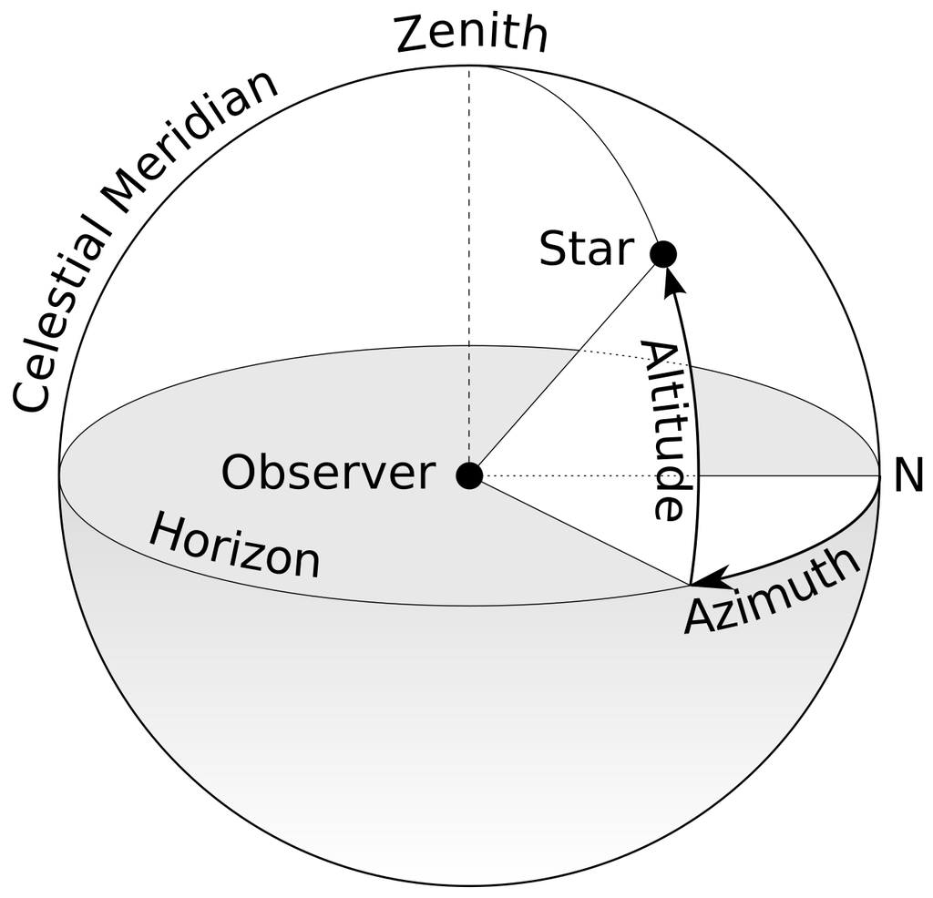

Of course, we are not studying astronomy to learn about navigation, but we use the same ideas to navigate in the night sky as we do under it. To define longitude, we need to decide what to use as the **fundamental plane** (instead of the equatorial plane). There are many options, but a good place to start is to take our own vantage point (from wherever we are on Earth) and the horizon that comes with it. Then instead of, say $45{^\circ}$ north of the equator, we might say $7{^\circ}$ north of the horizon. (Where did I get $7{^\circ}$? Did I just make this up?) This coordinate is called the **altitude**.<sup>2</sup> The point directly overhead is called the **zenith**. It has altitude $90{^\circ}$. To define a coordinate for longitude, we need the analog of the prime meridian. We take this to be given by the plane that *passes through the north pole (and our position) and is orthogonal to the horizon*, in other words, we start by facing north and measure the angle horizontally from there. The convention is to do this in eastward direction. This coordinate is called the **azimuth**. This celestial coordinate system is called the [Horizontal coordinate system](https://en.wikipedia.org/wiki/Horizontal_coordinate_system).

### Problem 5.

> Go outside and find the altitude and azimuth of the Moon. Make a note of your position on Earth and the time of day/night.

In the previous problem, we are faced with the difficulty of determining two angles with limited tools. For example, for azimuth we will need a compass (to determine which direction is North). A device used to determine the altitude is called a **sextant**.

### Problem 6.

> Think about how to construct a sextant from household materials and then make one from scratch. A simple way of doing this uses a protractor, a small drinking straw, and a bob. The goal is to design something that you can look through to tell you the angle of altitude of an object in the sky.
> 1. By taking careful measurements, estimate to what accuracy you can trust angular altitudes as determined with your sextant. For example, is it accurate to within $2{^\circ}$? How about $1{^\circ}$? $0.5{^\circ}$??

> Whatever number you settle on here is called the **uncertainty** inherent in any measurement you make with this device. If you decide it is accurate to within $1{^\circ}$, then when you measure an angle of $29{^\circ}$, the actual angle could be as large as $30{^\circ}$ and as small as $28{^\circ}$.
> 2. Describe the features of your sextant that are contributing the most to your uncertainty and justify your claimed uncertainty.
> 3. Go back and confirm or modify your answer to question 4. Explain your conclusion clearly.
> 4. Describe the construction of a sextant that you could make that would be more accurate (*i.e.* that would have a smaller inherent uncertainty).

### Astranatomy

It may happen that you are out and about in the world and you notice something that piques your curiosity like a tall tower or an **asterism** you had not noticed before. In these situations, it could be useful to know the angular size of a comparable object. For example, if you know that the tip of your index finger when extended as far from your eyes as possible is roughly $1{^\circ}$, you can use this to estimate that the size of the moon is roughly $0.5{^\circ}$.<sup>3</sup>

### Problem 7.

> Everyone’s anatomy is different, so in this problem, we will find the angular sizes of your hand with the aim of using it to find angular sizes in the sky. This can be done alone, but it is easiest to work with a partner. Stand with fully outstretched arm (right or left) so that your middle finger is as far from your face as possible. Close one eye (remember which one it is!) and look down your arm at your finger. (Note that if your finger is as far away from your face as possible, you should be facing sideways at this point.)
> 1. Have a partner help you measure the distance from your open eye to the tip of your middle finger.
> 2. Measure the width of the nail on your middle finger. Use this and the answer from a. to find the angular size in degrees of your nail when it is this far from your face. Your answer should be around $1{^\circ}$.
> 3. Now stretch out your hand and measure the largest distance from the tip of your thumb to the tip of your pinky finger. Have your partner re-measure the distance of your hand to your eye. (It should be slightly less than what you found in part a.) Make note of these two measurements and use them to find the angular size (in degrees) of your outstretched hand.
> 4. Repeat the steps for a fist. First measure the angular size of the full width of your fist and then measure knuckle-to-knuckle.

A useful mnemonic is that your finger is around $1{^\circ}$, your fist is around $10{^\circ}$ (so half of it is around $5{^\circ}$), and your outstretched hand is between $15{^\circ}$ and $20{^\circ}$.

### Problem 8.

> Using a star chart you can get from class, locate the constellation Ursa Major (UMa) in the night sky. (If you cannot see stars well enough to make out Ursa Major, find another constellation and make note of which one it is.) Note the time and place of your measurement. Using the results from problem 6,
> 1. estimate the altitude and azimuth of the constellation,
> 2. estimate the angular length of the Big Dipper asterism.
> 3. Find the Polaris (the north star), and use your sextant to carefully measure its altitude. What is its azimuth?

<sup>1</sup> See also More Precisely 1-1 on page 14 of the textbook.

<sup>2</sup> This is sometimes (confusingly) called “elevation”. We will refrain from using this word because it is more commonly used in astronomical circles to refer to the height above sea level.

<sup>3</sup> This is also the angular size of the Sun, which is why we can have **total eclipses** and **annular eclipses**.